# Assignment 5

Isabel

10/11/2019

```r
suppressPackageStartupMessages(library(gapminder))
suppressPackageStartupMessages(library(tidyverse))
suppressPackageStartupMessages(library(dplyr))
suppressPackageStartupMessages(library(ggplot2))
suppressPackageStartupMessages(library(here))
suppressPackageStartupMessages(library(reshape2))
```

## Exercise 1

*What’s the value of using the here::here package?*

Rstudio projects allow us to establish a fresh session (with its own environment and packages), and avoid having to set our working directory.

The here::here package makes it even easier for us to work with Rstudio projects because:

1. It helps us to find the underlying root directory that our project is located in
2. It helps us to get around the problem of working with different OS: different OS have different ways of writing file pathways - so if you are using a mac but your collaborator is using windows, they will not be able to run your scripts.

In other words, one of the biggest benefits of using R is that it makes your code more replicable regardless of which computer or R session it is running in.

## Exercise 2

We first ensure that the variable continent is indeed a factor variable.

```r
class(gapminder$continent)
```

```
## [1] "factor"
```

We then check how many levels of factors the variable continent has, as well as how many rows of observation the current gapminder dataset has.

```r
nlevels(gapminder$continent)
```

```
## [1] 5
```

```r
nrow(gapminder)
```

```
## [1] 1704
```

We plot the mean GDP per capita according to continent.

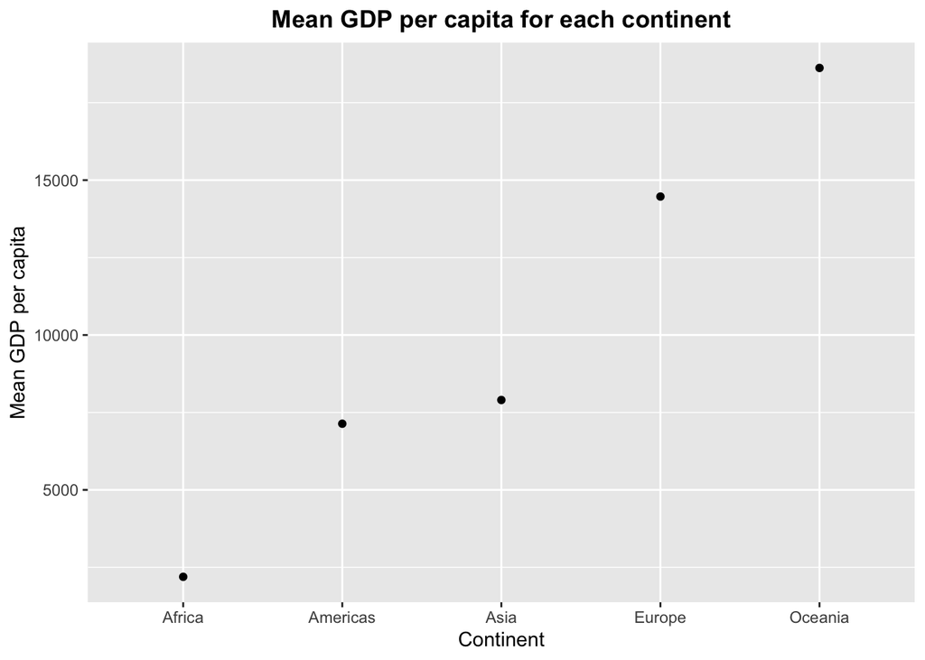

```r
gapminder%>%
  group_by(continent)%>%
  summarise(mean_gdp=mean(gdpPercap))%>%
  ggplot() +
  geom_point(aes(x=continent, y=mean_gdp))+
  xlab("Continent") + ylab("Mean GDP per capita")+
  ggtitle("Mean GDP per capita for each continent")+
  theme(plot.title=element_text(hjust=0.5, face="bold"))
```

Let’s now drop Oceania by filtering the gapminder data to remove associations with the continent of Oceania. After doing so, we will check the number of factor levels and observations in the dataset.

```r
gapminder_filtered<-gapminder%>%
  filter(continent!="Oceania")

nlevels(gapminder_filtered$continent)
```

```
## [1] 5
```

```r
nrow(gapminder_filtered)
```

```
## [1] 1680
```

We can see that although we have fewer rows in the dataset after filtering out Oceania, the number of factor levels remain the same. Let’s now drop the unused factor level. Once we do that, we can see that we only have 4 factor levels for the variable continent.

```r
gapminder_filtered_drop<-gapminder_filtered%>%
  droplevels()

gapminder_filtered_drop$continent %>%
  nlevels()
```

```
## [1] 4
```

When we run the same scatterplot as before, we can see that Oceania is now removed.

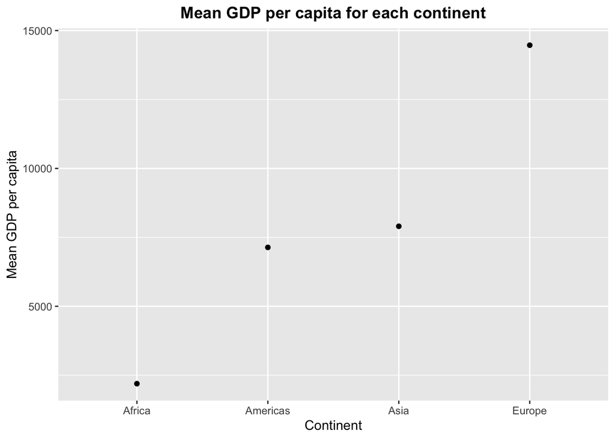

```r
gapminder_filtered_drop%>%
  group_by(continent)%>%
  summarise(mean_gdp=mean(gdpPercap))%>%
  ggplot() +
  geom_point(aes(x=continent, y=mean_gdp)) +
  xlab("Continent") + ylab("Mean GDP per capita")+
  ggtitle("Mean GDP per capita for each continent")+
  theme(plot.title=element_text(hjust=0.5, face="bold"))
```

Let’s look at the median life expectancy for each continent.

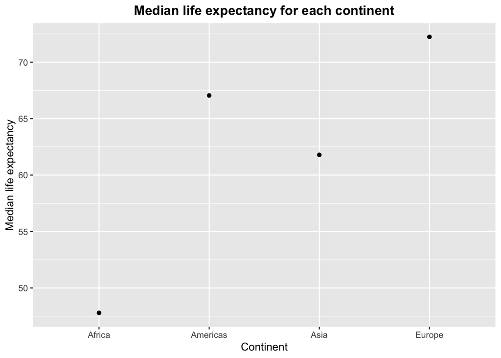

```r
gapminder_filtered_drop%>%
  group_by(continent)%>%
  summarise(median_life=median(lifeExp))%>%
  ggplot() +
  geom_point(aes(x=continent, y=median_life)) +
  xlab("Continent") + ylab("Median life expectancy")+
  ggtitle("Median life expectancy for each continent")+
  theme(plot.title=element_text(hjust=0.5, face="bold"))
```

Let’s reorder the level in ascending order of the median life expectancy.

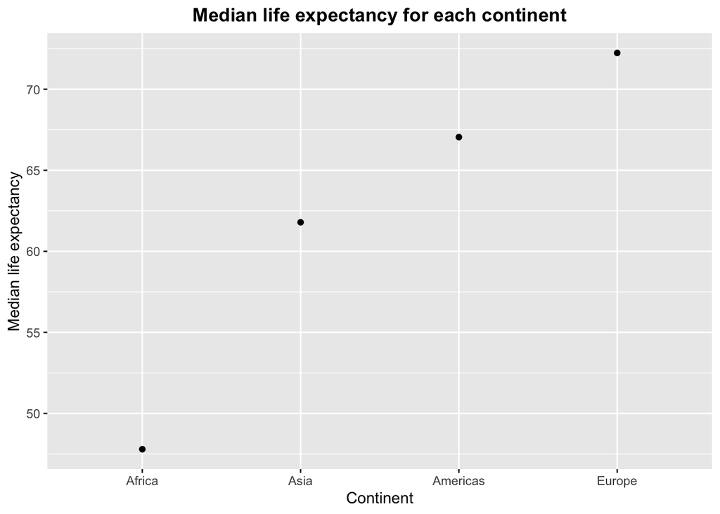

```r
gapminder_filtered_drop%>%
  group_by(continent)%>%
  summarise(median_life=median(lifeExp))%>%
  ggplot() +
  geom_point(aes(fct_relevel(continent, "Africa", "Asia"), y=median_life)) +
  xlab("Continent") + ylab("Median life expectancy")+
  ggtitle("Median life expectancy for each continent")+
  theme(plot.title=element_text(hjust=0.5, face="bold"))
```

## Exercise 3

For this exercise, I will export a modified version of the gapminder dataset and reload it back into R.

I first modify the gapminder dataset by creating a summarised dataset consisting of the mean life expectancy for each continent.

```r
gapminder1<-gapminder%>%
  group_by(continent)%>%
  summarise(mean_life=mean(lifeExp))
```

I then write it to my disk.

```r
write_csv(gapminder1, here::here("data", "assignment5", "gapminder1.csv"))
```

I now want to reimport it to R.

```r
gapminder_import<-read_csv(here::here("data", "assignment5", "gapminder1.csv"))
gapminder_import
```

```
## # A tibble: 5 x 2
##   continent mean_life
##   <chr>         <dbl>
## 1 Africa         48.9
## 2 Americas       64.7
## 3 Asia           60.1
## 4 Europe         71.9
## 5 Oceania        74.3
```

When we reimported the gapminder1 dataset back into R, we noticed that the variable continent was reimported as a character variable. Let’s use the forcat package to convert it into a factor variable.

```r
gapminder_import<-gapminder_import%>%
  mutate(continent=fct_lump(continent, n=5))

#Let's check to make sure that the variable continent has indeed been converted into a factor with 5 levels
str(unique(gapminder_import$continent))
```

```
##  Factor w/ 5 levels "Africa","Americas",..: 1 2 3 4 5
```

Once we have done that, we can now plot a graph showing mean life expectancy across continents. We want to ensure that the continents are ordered in ascending order of mean life expectancy.

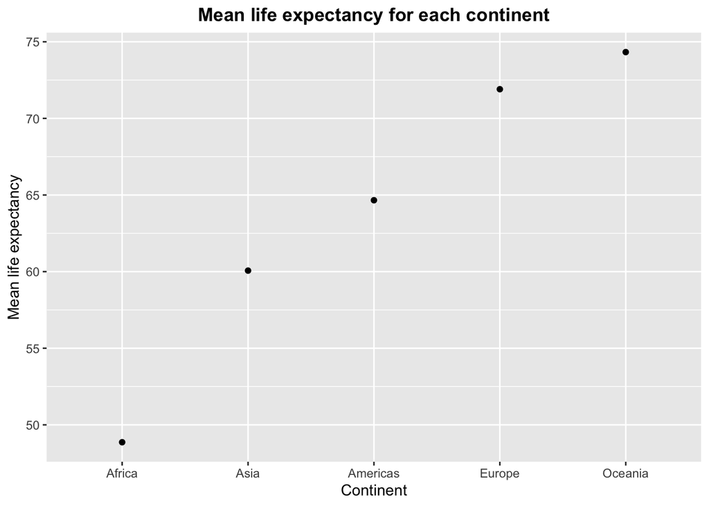

```r
gapminder_import%>%
  ggplot() +
  geom_point(aes(fct_relevel(continent, "Africa", "Asia"), mean_life)) +
  xlab("Continent") + ylab("Mean life expectancy")+
  ggtitle("Mean life expectancy for each continent")+
  theme(plot.title=element_text(hjust=0.5, face="bold"))
```

## Exercise 4

For a previous exercise, I had constructed a graph that compares the minimum and maximum GDP per capita for each continent. Initially, my graph included two separate plots (1 showing the minimum GDP per capita and the second showing the maximum GDP per capita) stacked on top of one another. However, this made it difficult to compare the minimum and maximum GDP per capita for each continent, and may also be misleading because of the different y-axis scale.

For instance, if we look at the graphs for Oceania, we might think that the maximum GDP per capita is lower than the minimum GDP per capita. However, this is simply due to the difference y-axis scale used.

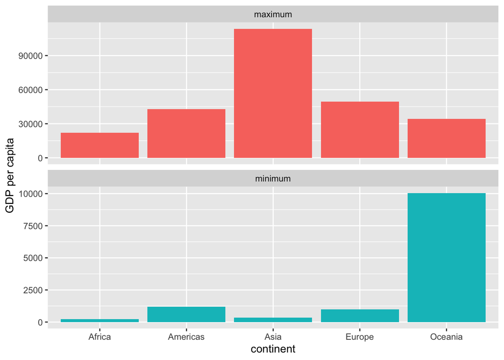

```r
minmax<-gapminder%>%
  group_by(continent)%>%
  mutate(maximum=max(gdpPercap))%>%
  mutate(minimum=min(gdpPercap))%>%
  select(continent, maximum, minimum)%>%
  distinct()%>%
  as_tibble()

minmax1<-melt(minmax, id.vars=1)

minmax1%>%
  ggplot(aes(continent, value, fill=variable))+
  geom_col(position="dodge")+
  facet_wrap(~variable, ncol=1, scales="free_y")+
  theme(legend.position="none")+
  ylab("GDP per capita")
```

Another modification I have made since that assignment is that rather than use the melt function from the reshape2 package, I now use the pivot_longer function from the tidyverse package to lengthen my dataset so as to be able to create the type of graph I am interested in.

My updated graph now allows for comparison of the minimum and maximum GDP per capita not just between continents, but also within continents. Because of the y-axis scale used, it is difficult to make out the values for the minimum GDP per capita. As such, I have done away with the y-axis completely, and labelled the bars directly, so that a consumer of my graph can note down straightaway the value of each bar.

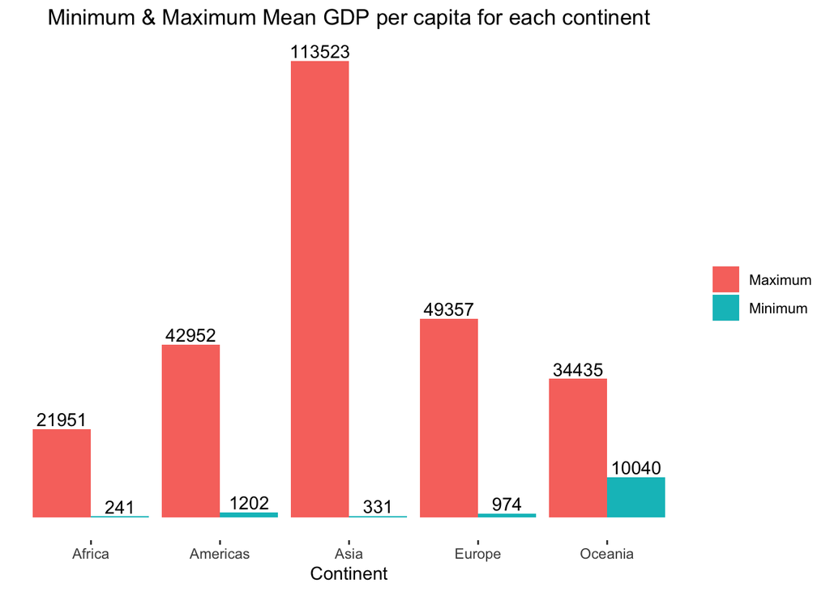

```r
minmax_long<-minmax%>%
  pivot_longer(cols=c("maximum", "minimum"),
               names_to="min_max",
               values_to="gdp_per_cap")

graph<-minmax_long%>%
  ggplot(aes(continent, gdp_per_cap, fill=min_max))+
  geom_bar(stat="identity", position="dodge")+
  geom_text(aes(label=round(gdp_per_cap, digits=0)), position=position_dodge(width=0.9), vjust=-0.25)+
  ggtitle("Minimum & Maximum Mean GDP per capita for each continent")+
  labs(x="Continent", y="GDP per capita")+
  scale_fill_discrete(labels=c("Maximum", "Minimum"))+
  theme(plot.title=element_text(hjust=0.5),
        panel.grid=element_blank(),
        panel.background=element_blank(),
        axis.title.y=element_blank(),
        axis.text.y=element_blank(),
        axis.ticks.y=element_blank(),
        legend.title = element_blank())

graph
```

## Exercise 5

We want to indicate the plot object in the function because ggsave takes the last graph that was created. Although in this situation it works fine because the last graph created is indeed the plot that we want to save, this can be problematic if we create other graphs prior to running ggsave.

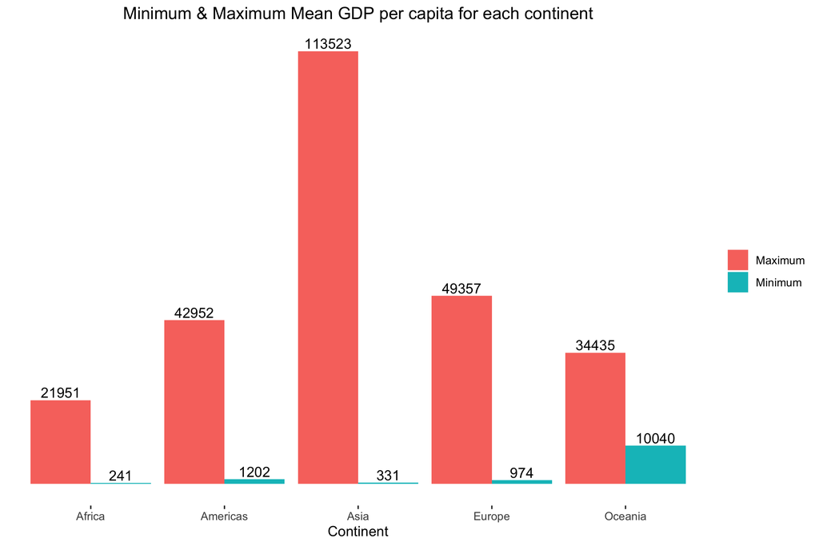

```r
ggsave(here("Assignment 5", "GDPpercap.png"), plot=graph, scale=1.5, width=15, height=10, units=c("cm"))
```